# Cluster Analysis using Package mlr

Data Mining

Description for Cluster Analysis using Package mlr

Yeongeun Jeon , Jung In Seo  
2023-07-10

> k-means의 장점
- 안정적인 결과를 찾을 때까지 각 반복마다 군집 간에 case 이동이 가능하다.
- 예측 변수가 많은 경우, 다른 군집분석 알고리듬에 비해 수행하는 시간이 적게 걸린다.
- 알고리듬 구현이 매우 간단하다.

> k-means의 단점
- 범주형 예측 변수는 거리 계산을 할 수 없으므로 분석에 사용할 수 없다.
- 군집의 개수를 미리 결정해야 한다.
- 예측 변수들의 scale을 동일하게 설정해야 한다.
- 이상치에 민감하다.
- 초기 중심값 선택에 매우 민감하다.
- 비구형 군집에는 잘 작동하지 않는다.

> 실습 자료 : “USArrests” 데이터셋은 1973년 미국의 50개 주별로 살인(Murder), 폭행(Assault) 그리고 강간(Rape) 범죄의 10만명당 체포 건수와 도시 인구 비율을 포함하고 있다.

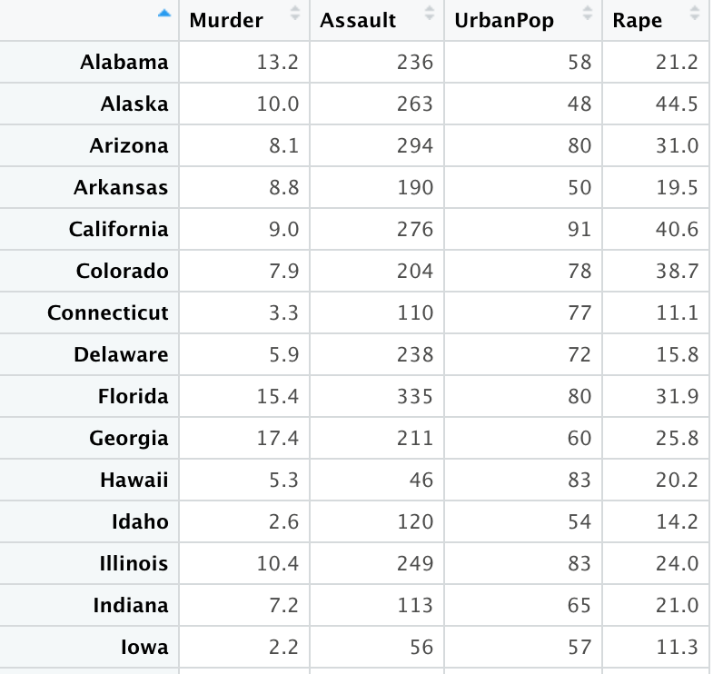

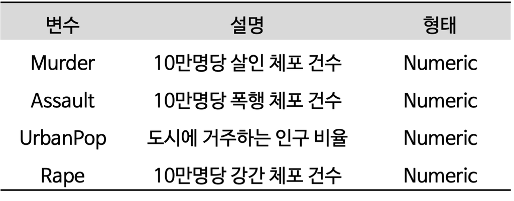

# **Contents**

- 데이터 불러오기
- 데이터 탐색
- 데이터 분할
- 데이터 전처리
- 모형 훈련
- 예측

# **1. 데이터 불러오기**

```r
pacman::p_load("data.table",
               "tidyverse",
               "dplyr",
               "caret",
               "GGally",                       # For ggpairs
               "mlr",
               "clue",
               "parallelMap",                  # For parallelStartSocket
               "parallel")                     # For detectCores

data("USArrests")                              # 데이터 불러오기

USArrests %>%
  as_tibble
```

```
# A tibble: 50 × 4
   Murder Assault UrbanPop  Rape
    <dbl>   <int>    <int> <dbl>
 1   13.2     236       58  21.2
 2   10       263       48  44.5
 3    8.1     294       80  31
 4    8.8     190       50  19.5
 5    9       276       91  40.6
 6    7.9     204       78  38.7
 7    3.3     110       77  11.1
 8    5.9     238       72  15.8
 9   15.4     335       80  31.9
10   17.4     211       60  25.8
# ℹ 40 more rows
```

# **2. 데이터 탐색**

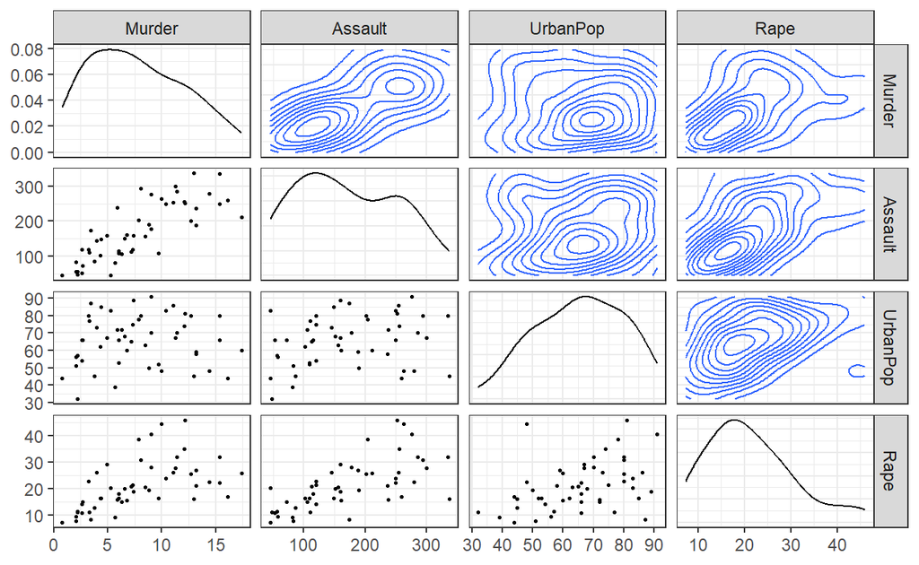

```r
ggpairs(USArrests,
        upper = list(continuous = "density"),
        lower = list(continuous = wrap("points", size = 0.5)),
        diag = list(continuous = "densityDiag")) +
  theme_bw()
```

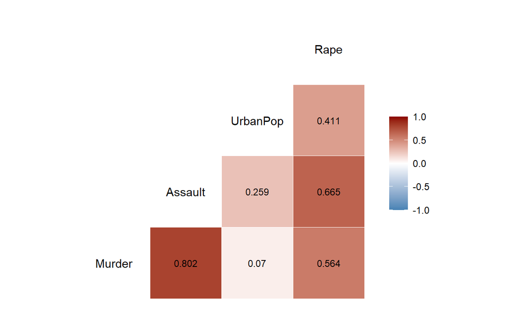

```r
# 상관계수 그래프
ggcorr(USArrests,               # 데이터
       label = TRUE,            # 라벨 명시 여부
       label_round = 3,         # 상관계수 소숫점 이하 자릿수
       label_size = 3,          # 상관계수 글자 크기
       low = "steelblue",       # 상관계수가 음수일 때 색깔
       mid = "white",           # 상관계수가 0에 가까울 때 색깔
       high = "darkred")        # 상관계수가 양수일 때 색깔
```

# **3. 데이터 분할**

```r
# Partition (Training Dataset : Test Dataset = 8:2)
set.seed(200)
ind <- sample(1:nrow(USArrests), 0.8*nrow(USArrests))       # Index를 이용하여 8:2로 분할

USArrests.trd <- USArrests[ind,]                            # Training Dataset
USArrests.ted <- USArrests[-ind,]                           # Test Dataset
```

# **4. 데이터 전처리**

```r
# Standardization
preProcValues <- preProcess(USArrests.trd,
                            method = c("center", "scale"))  # Standardization 정의 -> Training Dataset에 대한 평균과 표준편차 계산

USArrests.trd <- predict(preProcValues, USArrests.trd)      # Standardization for Training Dataset
USArrests.ted <- predict(preProcValues, USArrests.ted)      # Standardization for Test Dataset

glimpse(USArrests.trd)                                      # 데이터 구조 확인
```

```
Rows: 40
Columns: 4
$ Murder   <dbl> -0.28335915, -0.82987994, 1.64134450, -1.13878299, …
$ Assault  <dbl> -0.66262772, -0.20320584, 1.37532065, -1.06314937, …
$ UrbanPop <dbl> 0.56553882, 0.63579209, -1.12053964, 0.14401920, 1.…
$ Rape     <dbl> -0.62276898, 0.61022086, 0.20649852, -0.62276898, 2…
```

```r
glimpse(USArrests.ted)                                      # 데이터 구조 확인
```

```
Rows: 10
Columns: 4
$ Murder   <dbl> 0.5958265, 1.8789622, 2.3541977, -1.1625448, 0.6908…
$ Assault  <dbl> 1.1868399, 2.0350034, 0.5742774, -0.4977070, 1.0219…
$ UrbanPop <dbl> -1.1205396, 1.1275650, -0.2775004, -0.6990200, 1.33…
$ Rape     <dbl> 2.6070097, 1.2321715, 0.5665752, -0.6991489, 0.3701…
```

# **5. 모형 훈련**

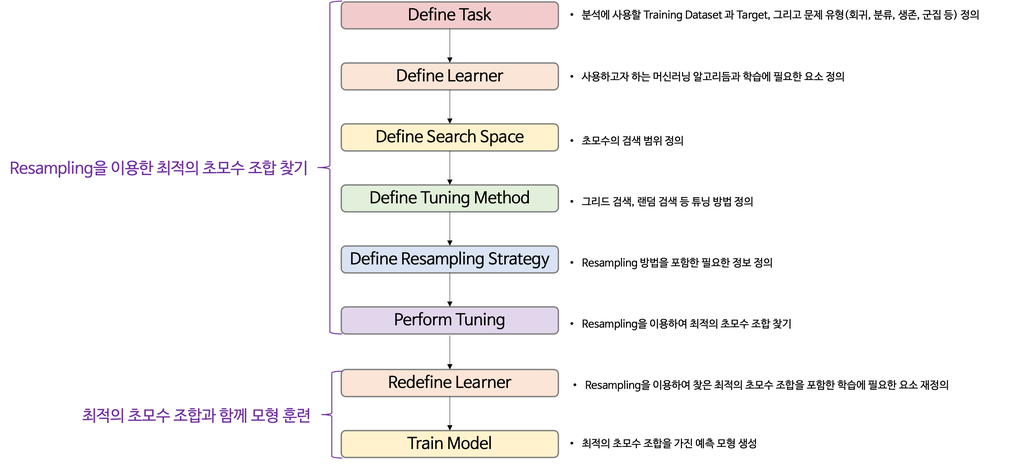

## **5-1. Resampling을 이용한 최적의 초모수 조합 찾기**

### **5-1-1. Define Task**

- 문제 유형에 따라 Task를 정의하는 데 사용하는 함수는 다음과 같다.

| 문제 유형 | 함수 |
| --- | --- |
| 회귀 문제 | `makeRegrTask()` |
| 이진 또는 다중 클래스 분류 문제 | `makeClassifTask()` |
| 생존분석 | `makeSurvTask()` |
| 군집분석 | `makeClusterTask()` |
| 다중 라벨 분류 문제 | `makeMultilabelTask()` |
| 비용 민감 분류 문제 | `makeCostSensTask()` |

```r
## k-means : 군집분석
USArrests.Task <- makeClusterTask(data = USArrests.trd)   # Training Dataset
USArrests.Task
```

```
Unsupervised task: USArrests.trd
Type: cluster
Observations: 40
Features:
   numerics     factors     ordered functionals
          4           0           0           0
Missings: FALSE
Has weights: FALSE
Has blocking: FALSE
Has coordinates: FALSE
```

### **5-1-2. Define Learner**

- 학습자(Learner)는 함수 `makeLearner()`를 이용하여 정의한다.
- 함수 `makeLearner()`의 첫 번째 인자 `cl`에는 사용하고자 하는 머신러닝 알고리듬을 `문제 유형.알고리듬과 관련된 R 함수 이름` 형태로 입력한다.
  - 예를 들어,
    - 회귀 문제 : `"regr.알고리듬과 관련된 R 함수 이름"`
    - 클래스 분류 문제 : `"classif.알고리듬과 관련된 R 함수 이름"`
    - 생존분석 : `"surv.알고리듬과 관련된 R 함수 이름"`
    - 군집분석 : `"cluster.알고리듬과 관련된 R 함수 이름"`
    - 다중 라벨 문제 : `"multilabel.알고리듬과 관련된 R 함수 이름"`
  - Package `"mlr"`에서 사용할 수 있는 알고리듬은 [여기](https://mlr.mlr-org.com/articles/tutorial/integrated_learners.html)를 통해서 확인할 수 있다.

```r
# 초모수 집합
getParamSet("cluster.kmeans")  # cluster.kmeans : Clustering based on "kmeans" function
```

```
              Type len           Def
centers    untyped   -             -
iter.max   integer   -            10
nstart     integer   -             1
algorithm discrete   - Hartigan-Wong
trace      logical   -             -
                                      Constr Req Tunable Trafo
centers                                    -   -    TRUE     -
iter.max                            1 to Inf   -    TRUE     -
nstart                              1 to Inf   -    TRUE     -
algorithm Hartigan-Wong,Lloyd,Forgy,MacQueen   -    TRUE     -
trace                                      -   -   FALSE     -
```

`Caution!` 특정 머신러닝 알고리듬이 가지고 있는 초모수는 함수 `getParamSet()`를 이용하여 확인할 수 있다.

```r
USArrests.Learner <- makeLearner(cl = "cluster.kmeans",                # 함수 kmeans를 이용하여 군집분석 수행
                                 par.vals = list(iter.max = 100,       # 최대 반복 수
                                                 nstart = 25))         # 수행 횟수
USArrests.Learner
```

```
Learner cluster.kmeans from package stats,clue
Type: cluster
Name: K-Means; Short name: kmeans
Class: cluster.kmeans
Properties: numerics,prob
Predict-Type: response
Hyperparameters: centers=2,iter.max=100,nstart=25
```

`Caution!` 함수 `makeLearner()`의 인자 `par.vals`에 함수 `kmeans()`의 옵션을 입력할 수 있다. `iter.max`에는 최대 반복 수를, `nstart`에는 k-means 수행 횟수를 지정할 수 있다. k-means는 초기 중심값을 랜덤하게 선택하기 때문에 이 과정에서 다양한 결과가 나타날 수 있다. 그래서 옵션 `nstart`를 이용하여 수행 횟수를 늘려 최대한 다양한 초기 중심값에 대해 k-means를 수행하고 최적의 결과를 찾을 수 있다.

### **5-1-3. Define Search Space**

- 함수 `makeDiscreteParam()` 또는 `makeNumericParam()`을 이용하여 초모수의 검색 범위를 정의한다.
  - 함수 `makeDiscreteParam()` : 검색 범위를 특정값으로 정의하는 경우 사용
  - 함수 `makeNumericParam()` : 검색 범위를 구간으로 정의하는 경우 사용
- 그러고나서, 함수 `makeParamSet()`를 이용하여 정의한 검색 범위을 `ParamSet` 객체로 만든다.

```r
# 초모수 "centers" (군집 수)와 알고리듬의 검색 범위 정의
tune.hyper <- makeParamSet(
  makeDiscreteParam("centers",                                         # 군집 수
                    values = 3:7),                                     # 군집 수에 대한 검색 범위
  makeDiscreteParam("algorithm",                                       # k-means 알고리듬
                    values = c("Lloyd", "MacQueen", "Hartigan-Wong"))) # 알고리듬에 대한 검색 범위
tune.hyper
```

```
              Type len Def                       Constr Req Tunable
centers   discrete   -   -                    3,4,5,6,7   -    TRUE
algorithm discrete   -   - Lloyd,MacQueen,Hartigan-Wong   -    TRUE
          Trafo
centers       -
algorithm     -
```

`Caution!` k-means를 수행하기 위해 “Lloyd”, “MacQueen” 그리고 “Hartigan-Wong” 알고리듬을 검색 범위로 정의하였다. 각 알고리듬의 수행 절차는 다음과 같다.

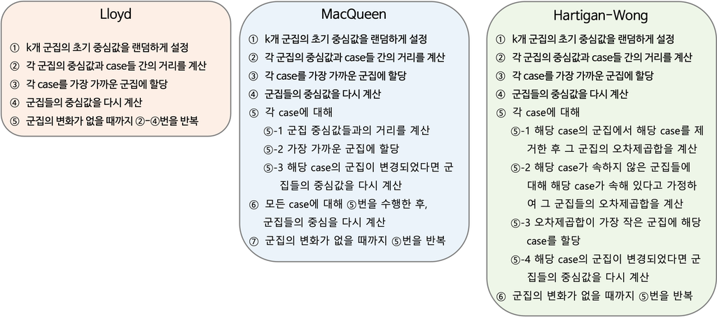

### **5-1-4. Define Tuning Method**

- 정의한 검색 범위 내에서 후보 초모수 조합을 찾는다.
- 가장 많이 사용하는 방법은 그리드 검색(Grid Search)과 랜덤 검색(Random Search)이며, 각각 함수 `makeTuneControlGrid()`와 `makeTuneControlRandom()`을 이용하여 정의할 수 있다.

```r
gridSearch <- makeTuneControlGrid()                                    # 그리드 검색
gridSearch
```

```
Tune control: TuneControlGrid
Same resampling instance: TRUE
Imputation value: <worst>
Start: <NULL>

Tune threshold: FALSE
Further arguments: resolution=10
```

`Result!` 함수 `makeTuneControlGrid()`를 이용하여 위에서 정의한 초모수 “centers”와 알고리듬의 검색 범위에 해당하는 모든 조합을 후보 초모수 조합으로 설정한다.

### **5-1-5. Define Resampling Strategy**

```r
kFold <- makeResampleDesc("CV", iters = 5)                             # 5-Fold Cross Validation
kFold
```

```
Resample description: cross-validation with 5 iterations.
Predict: test
Stratification: FALSE
```

### **5-1-6. Perform Tuning**

- 최적의 초모수 조합을 찾기 위해 함수 `tuneParams()`를 이용한다.

```r
parallelStartSocket(cpus = detectCores())                              # 병렬 처리

set.seed(100)
tunedK <- tuneParams(task = USArrests.Task,                            # Defined Task in 5-1-1
                     learner = USArrests.Learner,                      # Defined Learner in 5-1-2
                     par.set = tune.hyper,                             # Defined Search Space in 5-1-3
                     control = gridSearch,                             # Defined Tuning Method in 5-1-4
                     resampling = kFold,                               # Defined Resampling Strategy in 5-1-5
                     measures = list(silhouette))                      # Silhouette Index

tunedK
```

```
Tune result:
Op. pars: centers=4; algorithm=Lloyd
silhouette.test.mean=0.4363971
```

`Result!` 최적의 초모수 조합을 찾기 위해 “Silhouette Index”를 사용하였다. “Silhouette Index”는 다른 군집과 비교하여 case가 현재 속한 군집과 얼마나 유사한지를 나타내는 척도로 값이 높을수록 군집화가 잘 되었다는 것을 의미한다.

```r
tunedK$x$centers                                                       # 최적의 군집 수
```

```
[1] 4
```

```r
tunedK$x$algorithm                                                     # 최적의 알고리듬
```

```
[1] "Lloyd"
```

```r
# 튜닝 과정 시각화
kMeansTuningData <- generateHyperParsEffectData(tunedK)                # Extract Hyperparameter Effect from Tuning Result
kMeansTuningData$data
```

```
   centers     algorithm silhouette.test.mean iteration exec.time
1        3         Lloyd           0.38410327         1      0.48
2        4         Lloyd           0.43639711         2      0.47
3        5         Lloyd           0.28880857         3      0.47
4        6         Lloyd           0.16298416         4      0.50
5        7         Lloyd           0.14641453         5      0.48
6        3      MacQueen           0.38012986         6      0.46
7        4      MacQueen           0.42428022         7      0.06
8        5      MacQueen           0.34982859         8      0.06
9        6      MacQueen           0.18721157         9      0.09
10       7      MacQueen           0.08485767        10      0.10
11       3 Hartigan-Wong           0.38012986        11      0.08
12       4 Hartigan-Wong           0.42428022        12      0.07
13       5 Hartigan-Wong           0.31448170        13      0.09
14       6 Hartigan-Wong           0.17279832        14      0.09
15       7 Hartigan-Wong           0.12861509        15      0.06
```

```r
# 데이터 구조 변환
TuningData <- pivot_longer(kMeansTuningData$data,
                           cols = -c(centers, iteration, algorithm, exec.time),
                           names_to = "Metric",
                           values_to = "Value")

TuningData %>%
  as_tibble
```

```
# A tibble: 15 × 6
   centers algorithm     iteration exec.time Metric              Value
     <int> <chr>             <int>     <dbl> <chr>               <dbl>
 1       3 Lloyd                 1    0.480  silhouette.test.m… 0.384
 2       4 Lloyd                 2    0.470  silhouette.test.m… 0.436
 3       5 Lloyd                 3    0.470  silhouette.test.m… 0.289
 4       6 Lloyd                 4    0.5    silhouette.test.m… 0.163
 5       7 Lloyd                 5    0.480  silhouette.test.m… 0.146
 6       3 MacQueen              6    0.460  silhouette.test.m… 0.380
 7       4 MacQueen              7    0.0600 silhouette.test.m… 0.424
 8       5 MacQueen              8    0.0600 silhouette.test.m… 0.350
 9       6 MacQueen              9    0.0900 silhouette.test.m… 0.187
10       7 MacQueen             10    0.100  silhouette.test.m… 0.0849
11       3 Hartigan-Wong        11    0.0800 silhouette.test.m… 0.380
12       4 Hartigan-Wong        12    0.0700 silhouette.test.m… 0.424
13       5 Hartigan-Wong        13    0.0900 silhouette.test.m… 0.314
14       6 Hartigan-Wong        14    0.0900 silhouette.test.m… 0.173
15       7 Hartigan-Wong        15    0.0600 silhouette.test.m… 0.129
```

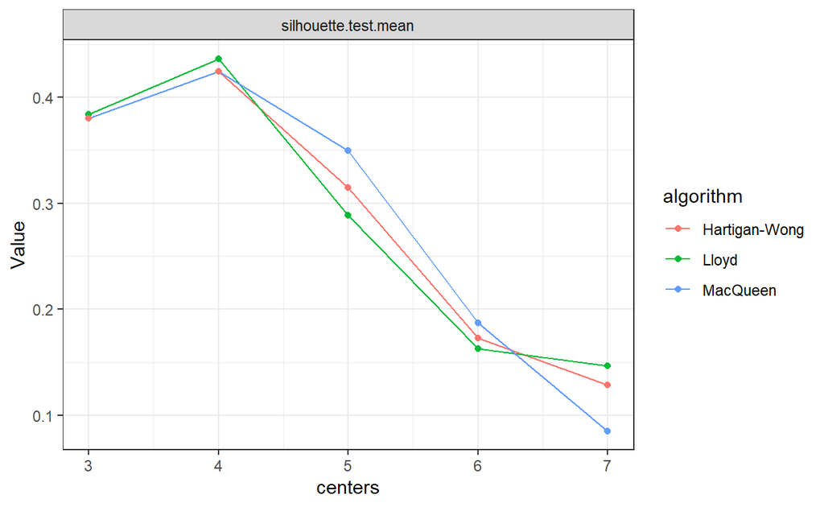

```r
ggplot(TuningData, aes(centers, Value, col = algorithm)) +
  facet_wrap(~ Metric, scales = "free_y") +
  geom_line() +
  geom_point() +
  theme_bw()
```

`Result!` 초모수 “centers = 4”이고 알고리듬이 “Lloyd”일 때 “Silhouette Index”값이 가장 높다는 것을 알 수 있다.

## **5-2. 최적의 초모수 조합과 함께 모형 훈련**

### **5-2-1. Redefine Learner**

```r
# Redefine Learner with 최적의 초모수 조합
tunedKMeans <- setHyperPars(USArrests.Learner,                               # Defined Learner in 5-1-2
                            par.vals = list(centers = tunedK$x$centers,      # 최적의 군집 수
                                            algorithm = tunedK$x$algorithm)) # 최적의 알고리듬
tunedKMeans
```

```
Learner cluster.kmeans from package stats,clue
Type: cluster
Name: K-Means; Short name: kmeans
Class: cluster.kmeans
Properties: numerics,prob
Predict-Type: response
Hyperparameters: centers=4,iter.max=100,nstart=25,algorithm=Lloyd
```

### **5-2-2. Train Model**

```r
tunedKMeansModel <- train(tunedKMeans,                                       # Defined Learner in 5-2-1
                          USArrests.Task)                                    # Defined Task in 5-1-1
tunedKMeansModel
```

```
Model for learner.id=cluster.kmeans; learner.class=cluster.kmeans
Trained on: task.id = USArrests.trd; obs = 40; features = 4
Hyperparameters: centers=4,iter.max=100,nstart=25,algorithm=Lloyd
```

```r
kMeanModel <- getLearnerModel(tunedKMeansModel)                              # 예측 모형 추출
kMeanModel
```

```
K-means clustering with 4 clusters of sizes 15, 7, 8, 10

Cluster means:
      Murder    Assault   UrbanPop       Rape
1 -0.4544439 -0.3736239  0.5280704 -0.1441216
2  1.4139104  1.0135049 -0.7793095  0.0194457
3  0.7354269  1.1323572  0.9607135  1.5267797
4 -0.8964129 -1.0549033 -1.0151597 -1.0188533

Clustering vector:
  Pennsylvania     Washington South Carolina      Minnesota
             1              1              2              1
        Nevada           Utah        Montana      Louisiana
             3              1              4              2
      Nebraska      Tennessee    Mississippi       Maryland
             1              2              2              3
  South Dakota       Delaware       Oklahoma     New Mexico
             4              1              1              3
      Colorado     New Jersey      Wisconsin       Virginia
             3              1              4              1
  North Dakota        Arizona         Hawaii  New Hampshire
             4              3              1              4
    California        Alabama       Michigan           Ohio
             3              2              3              1
        Oregon    Connecticut          Texas       Arkansas
             1              1              3              2
North Carolina          Maine        Indiana        Wyoming
             2              4              1              1
      Kentucky           Iowa        Vermont  West Virginia
             4              4              4              4

Within cluster sum of squares by cluster:
[1] 14.857404  7.103948  8.774396  9.673065
 (between_SS / total_SS =  74.1 %)

Available components:

[1] "cluster"      "centers"      "totss"        "withinss"
[5] "tot.withinss" "betweenss"    "size"         "iter"
[9] "ifault"
```

```r
# Training Dataset의 각 군집별 특징 시각화
USArrests.trd.clus <- mutate(USArrests.trd,
                             kMeansCluster = as.factor(kMeanModel$cluster))  # 예측 모형에 의한 군집 결과
USArrests.trd.clus %>%
  as_tibble
```

```
# A tibble: 40 × 5
   Murder Assault UrbanPop   Rape kMeansCluster
    <dbl>   <dbl>    <dbl>  <dbl> <fct>
 1 -0.283  -0.663    0.566 -0.623 1
 2 -0.830  -0.203    0.636  0.610 1
 3  1.64    1.38    -1.12   0.206 2
 4 -1.14   -1.06     0.144 -0.623 1
 5  1.12    1.06     1.20   2.77  3
 6 -1.02   -0.498    1.13   0.250 1
 7 -0.355  -0.627   -0.769 -0.459 4
 8  1.88    1.02     0.144  0.174 2
 9 -0.759  -0.710   -0.137 -0.448 1
10  1.36    0.303   -0.348  0.687 2
# ℹ 30 more rows
```

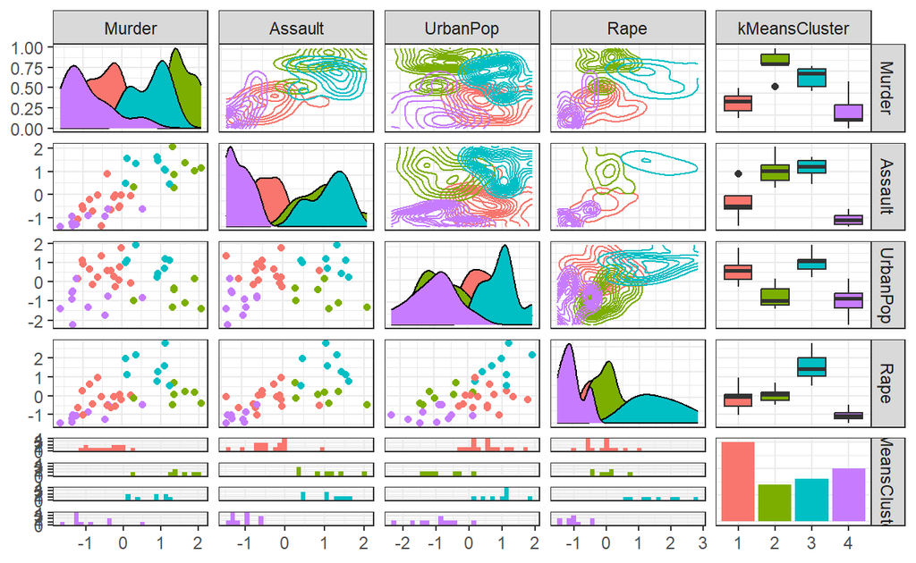

```r
ggpairs(USArrests.trd.clus, aes(col = kMeansCluster),
        upper = list(continuous = "density")) +
  theme_bw()
```

# **6. 예측**

```r
# 예측 군집 생성
Pred <- predict(tunedKMeansModel,
                newdata = USArrests.ted)         # predict(Trained Model, Test Dataset)
Pred %>%
  as_tibble
```

```
# A tibble: 10 × 1
   response
      <int>
 1        3
 2        3
 3        2
 4        4
 5        3
 6        1
 7        1
 8        3
 9        3
10        1
```